# Data Visualization in R

Prakash Lamichhane

2023-10-11

# 1 Introdcution to *ggplot2*

*ggplot2* is a popular data visualization package in R, developed by Hadley Wickham. It’s part of the tidyverse ecosystem and is widely used for creating elegant and customizable data visualizations. The name “ggplot2” stands for “Grammar of Graphics,” emphasizing its underlying philosophy of representing data visualization as a structured grammar.

## 1.1 Learn by examples

The functions in the ggplot2 package build up a graph in layers. We’ll build a complex graph by starting with a simple graph and adding additional elements, one at a time.

The example dataset is a tips dataset downloaded from the source link [tips_dataset](https://www.kaggle.com/datasets/ranjeetjain3/seaborn-tips-dataset/download?datasetVersionNumber=1).

First lets import the data in R.

```r
setwd("E:/broadwaylearning/R-Training/Data_visualization in R")
tips <- read.csv("tips.csv")
```

In building a ggplot2 graph, only the first two functions described below are required. The others are optional and can appear in any order.

### 1.1.1 ggplot package

The first function in building a graph is the ggplot function. It specifies the data frame to be used and the mapping of the variables to the visual properties of the graph. The mappings are placed within the **aes** function, which stands for aesthetics.

```r
# install if needed
if (!requireNamespace("ggplot2", quietly = TRUE)) {
  install.packages("ggplot2")
} # This code downloads and install the package only if it is not available before.
```

Let’s start by looking at the relationship between tip and total bill.

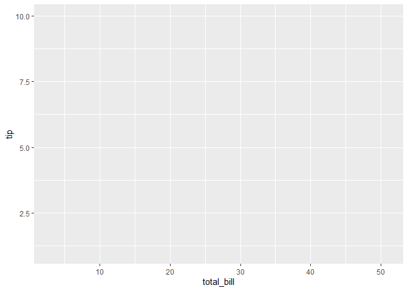

create a gpplot grapgh

```r
# Load library
library(ggplot2)

# specify dataset and mapping
ggplot(data = tips,
       mapping = aes(x = total_bill, y = tip))
```

We can see the empty box here. Because we have entered the x and y axis but did not specified what to show inside the graph. To specify it we have to add **geom()** to the plot.

### 1.1.2 Geom

Geoms are the geometric objects (points, lines, bars, etc.) that can be placed on a graph. They are added using functions that start with geom_. In this example, we’ll add points using the geom_point function, creating a scatterplot.

In ggplot2 graphs function are chained together using the **+** sign to build a final plot.

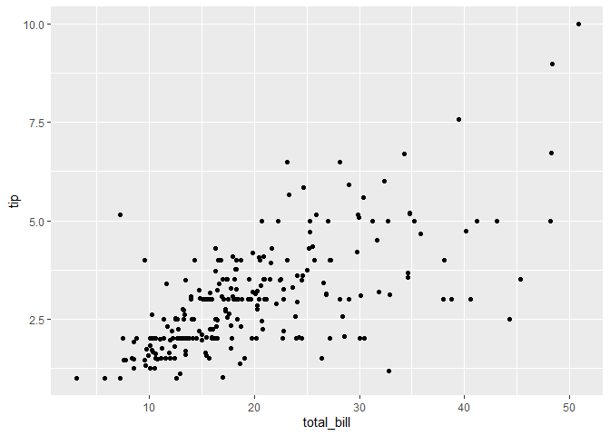

Add points to graph

```r
# add points on it
ggplot(data = tips,
       mapping = aes(x = total_bill, y = tip)) +
  geom_point()
```

A number of parameters(options) can be specified in a geom_ function. Options for the geom_point function include color, size, and alpha. These control the point color, size, and transparency, respectively.

Transparency ranges from 0 (completely transparent) to 1 (completely opaque). Adding a degree of transparency can help visualize overlapping points.

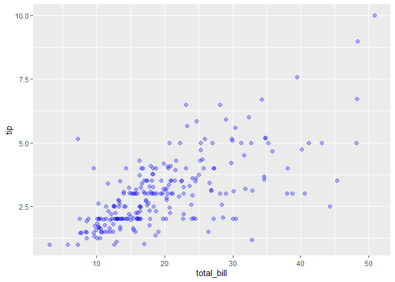

Modify point color, transparency, and size

```r
# Make color blue, larger points and semi transparent
ggplot(data = tips,
       mapping = aes(x = total_bill, y = tip)) +
  geom_point(color = 'blue',
             size = 2,
             alpha = 0.3)
```

Next, let’s add a line of best fit. We can do this with the geom_smooth function. Options control the type of line (linear, quadratic, nonparametric), the thickness of the line, the line’s color, and the presence or absence of a confidence interval. Here we request a linear regression (method = lm) line (where lm stands for linear model).

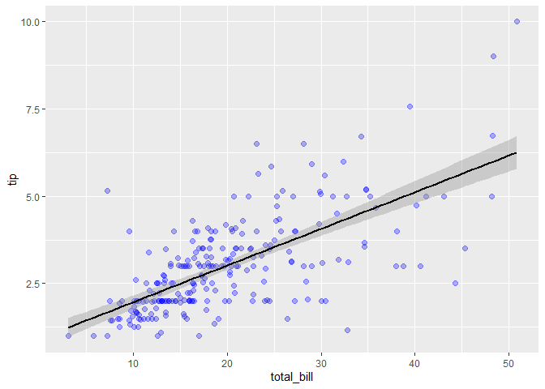

Add a best fit line and cutomize it

```r
# Make color blue, larger points and semi transparent
ggplot(data = tips,
       mapping = aes(x = total_bill, y = tip)) +
  geom_point(color = 'blue',
             size = 2,
             alpha = 0.3) +
  geom_smooth(method = "lm", color = 'black', se = TRUE)
```

### 1.1.3 Grouping

In addition to mapping variables to the x and y axes, variables can be mapped to the color, shape, size, transparency, and other visual characteristics of geometric objects. This allows groups of observations to be superimposed in a single graph.

Let’s add sex status to the plot and represent it by color.

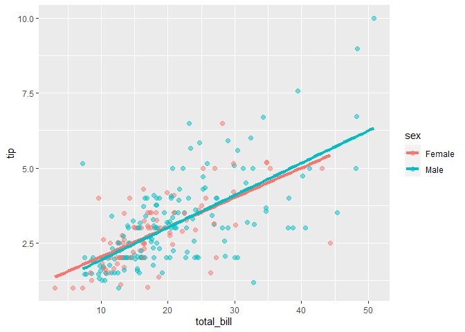

```r
# indicate sex using color
ggplot(data = tips,
       mapping = aes(x = total_bill,
                     y = tip,
                     color = sex)) +
  geom_point(alpha = .5,
             size = 2) +
  geom_smooth(method = "lm",
              se = FALSE,
              size = 1.5)
```

The color = sex option is place in the aes function, because we are mapping a variable to an aesthetic (a visual characteristic of the graph). The geom_smooth option (se = FALSE) was added to suppresses the confidence intervals.

### 1.1.4 Scales

Scales control how variables are mapped to the visual characteristics of the plot. Scale functions (which start with scale_) allow you to modify this mapping. In the next plot, we’ll change the x and y axis scaling, and the colors employed.

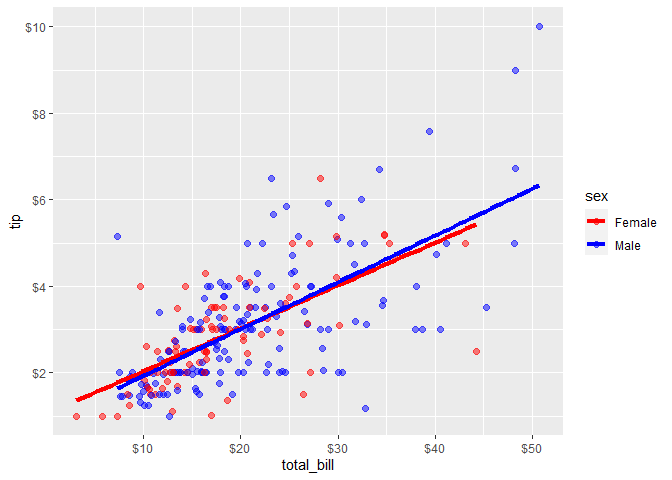

Adding scale to modify mapping

```r
# modifying the axis and its scale
ggplot(data = tips,
       mapping = aes(x = total_bill,
                     y = tip,
                     color = sex)) +
  geom_point(alpha = .5,
             size = 2) +
  geom_smooth(method = "lm",
              se = FALSE,
              size = 1.5) +
  scale_x_continuous(breaks = seq(0, 60, 10),
                     label = scales::dollar) +
  scale_y_continuous(breaks = seq(0, 10, 2),
                     label = scales::dollar) +
  scale_color_manual(values = c("red",
                                "blue"))
```

We’re getting there. Here is a question. Is the relationship between total bill, tips and sex the same for each days?

Let’s repeat this graph once for each day status in order to explore this.

### 1.1.5 Facet

Facets reproduce a graph for each level a given variable (or pair of variables). Facets are created using functions that start with facet_. Here, facets will be defined by the days in the data.

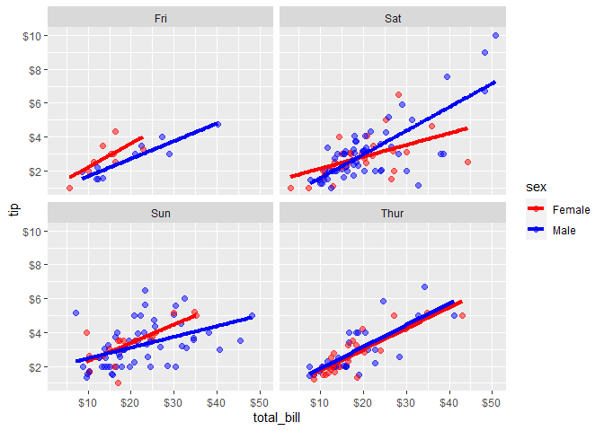

Separating the plots for each day.

```r
# adding days as facets
ggplot(data = tips,
       mapping = aes(x = total_bill,
                     y = tip,
                     color = sex)) +
  geom_point(alpha = .5,
             size = 2) +
  geom_smooth(method = "lm",
              se = FALSE,
              size = 1.5) +
  scale_x_continuous(breaks = seq(0, 60, 10),
                     label = scales::dollar) +
  scale_y_continuous(breaks = seq(0, 10, 2),
                     label = scales::dollar) +
  scale_color_manual(values = c("red",
                                "blue")) +
  facet_wrap(~day)
```

### 1.1.6 Labels

Graphs should be easy to interpret and informative labels are a key element in achieving this goal. The labs function provides customized labels for the axes and legends. Additionally, a custom title, subtitle, and caption can be added.

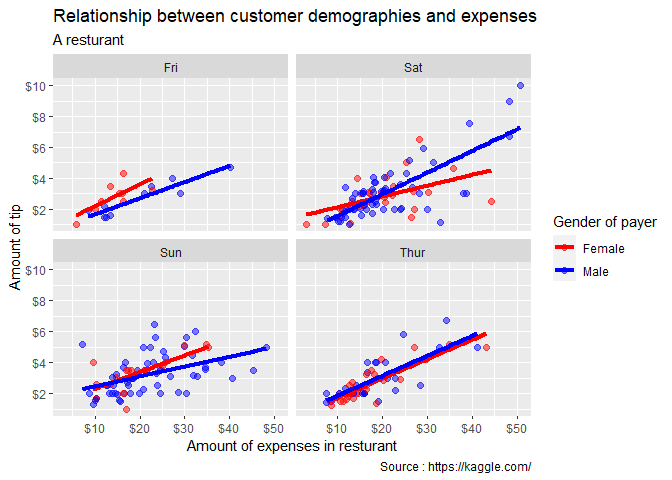

Adding labels to the graph

```r
# adding labels to graph
ggplot(data = tips,
       mapping = aes(x = total_bill,
                     y = tip,
                     color = sex)) +
  geom_point(alpha = .5,
             size = 2) +
  geom_smooth(method = "lm",
              se = FALSE,
              size = 1.5) +
  scale_x_continuous(breaks = seq(0, 60, 10),
                     label = scales::dollar) +
  scale_y_continuous(breaks = seq(0, 10, 2),
                     label = scales::dollar) +
  scale_color_manual(values = c("red",
                                "blue")) +
  facet_wrap(~day) +
  labs(title = "Relationship between customer demographies and expenses",
       subtitle = "A resturant",
       caption = "Source : https://kaggle.com/",
       x = "Amount of expenses in resturant",
       y = "Amount of tip",
       color = "Gender of payer")
```

### 1.1.7 Theme

Finally, we can fine tune the appearance of the graph using themes. Theme functions (which start with theme_) control background colors, fonts, grid-lines, legend placement, and other non-data related features of the graph. Let’s use a cleaner theme.

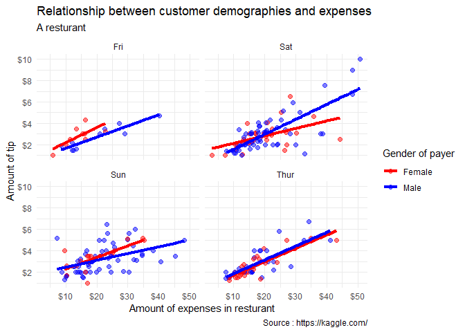

Modifying the themes for better look

```r
# Modify the theme of the grapgh
ggplot(data = tips,
       mapping = aes(x = total_bill,
                     y = tip,
                     color = sex)) +
  geom_point(alpha = .5,
             size = 2) +
  geom_smooth(method = "lm",
              se = FALSE,
              size = 1.5) +
  scale_x_continuous(breaks = seq(0, 60, 10),
                     label = scales::dollar) +
  scale_y_continuous(breaks = seq(0, 10, 2),
                     label = scales::dollar) +
  scale_color_manual(values = c("red",
                                "blue")) +
  facet_wrap(~day) +
  labs(title = "Relationship between customer demographies and expenses",
       subtitle = "A resturant",
       caption = "Source : https://kaggle.com/",
       x = "Amount of expenses in resturant",
       y = "Amount of tip",
       color = "Gender of payer")+
  theme_minimal()
```

## 1.2 Graph as object

A ggplot2 graph can be saved as a named R object (like a data frame), manipulated further, and then printed or saved to disk.

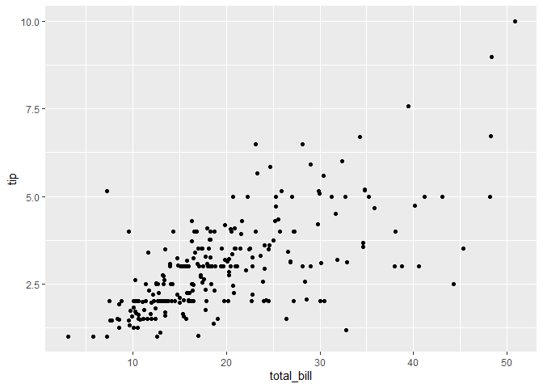

```r
# create scatterplot and save it
myplot <- ggplot(data = tips,
                  aes(x = total_bill, y = tip)) +
             geom_point()
# plot the grapgh
myplot
```

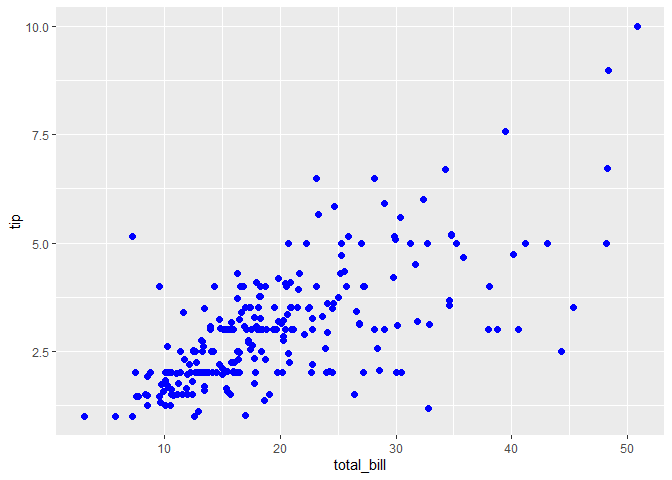

```r
# make the points larger and blue
# then print the graph
myplot <- myplot + geom_point(size = 2, color = "blue")
myplot
```

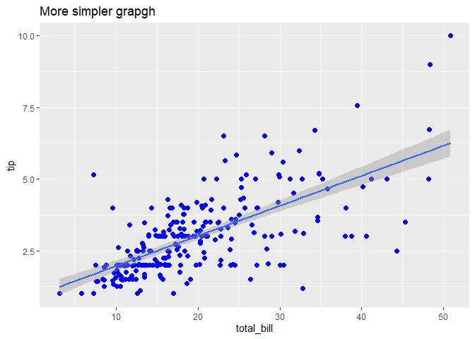

```r
# print the graph with a title and line of best fit
# but don't save those changes
myplot + geom_smooth(method = "lm") +
  labs(title = "More simpler grapgh")
```

# 2 Univariate Graph

The initial phase of a thorough data analysis process involves examining each individual variable separately. Univariate graphs are used to visualize the distribution of data for a single variable, which can be either categorical (such as race, sex, or political affiliation) or quantitative (like age, weight, or income).

In this analysis, we will focus on exploring the distribution of three specific variables sourced from the “Marriage” dataset. These variables include the ages and racial backgrounds of the individuals involved in the weddings, as well as the occupations of the officials who officiated the weddings. The dataset in question pertains to the marriage records of 98 individuals in Mobile County, Alabama.

## 2.1 Categorical

The race of the participants and the occupation of the officials are both categorical variables.The distribution of a single categorical variable is typically plotted with a bar chart, a pie chart, or (less commonly) a tree map or waffle chart.

### 2.1.1 Barchart

#### 2.1.1.1 Count / Frequency

Bar chart is used to display the distribution of categorical variable.

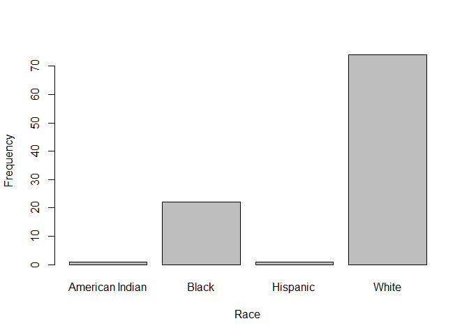

Bar chart by base R

```r
# Use base R
# install.packages("mosaicData")
library(mosaicData)

# plot with base R
# Plotting with base R requires the frequency table of the categorical variable.

barplot(table(Marriage$race),
        xlab = "Race",
        ylab = "Frequency")
```

It’s always better to graph using ggplot2 because it has better visualization technique and customizing options.

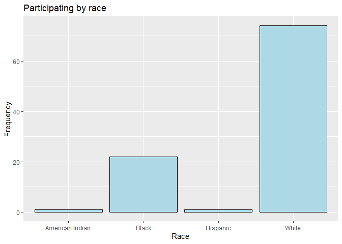

Bar chart by ggplot2 and customizing labels

```r
# Barplot using ggplot2
library(ggplot2)
library(mosaicData)

ggplot(data = Marriage,
       mapping = aes(x = race, y = after_stat(count))) +
  geom_bar(fill = 'lightblue',
           color = 'black') +
  labs(x = "Race",
       y = "Frequency",
       title = "Participating by race")
```

#### 2.1.1.2 Parcent

Bars can represent percentage in value (y-axis) rather than count or frequency. For bar charts, the code aes(x=race) is actually a shortcut for aes(x = race, y = after_stat(count)), where count is a special variable representing the frequency within each category. You can use this to calculate percentages, by specifying y variable explicitly.

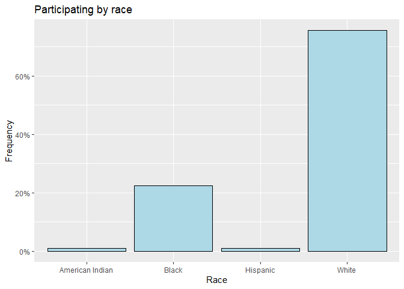

Bar chart by percentage

```r
# Barplot using ggplot2
library(ggplot2)
library(mosaicData)

ggplot(data = Marriage,
       mapping = aes(x = race, y = after_stat(count/sum(count)))) +
  geom_bar(fill = 'lightblue',
           color = 'black') +
  labs(x = "Race",
       y = "Frequency",
       title = "Participating by race")+
  scale_y_continuous(labels = scales::percent)
```

#### 2.1.1.3 Sorting categories

It is often helpful to sort the bars by frequency. In the code below, the frequencies are calculated explicitly. Then the reorder function is used to sort the categories by the frequency. The option stat=“identity” tells the plotting function not to calculate counts, because they are supplied directly.

```r
# calculate number of participants in each race category
library(dplyr)
```

```r
library(mosaicData)
plot_data <- Marriage %>%
  count(race)
knitr::kable(plot_data, caption = "Number of participants in each race", digits = 2)
```

Number of participants in each race

| race | n |
| --- | --- |
| American Indian | 1 |
| Black | 22 |
| Hispanic | 1 |
| White | 74 |

Now use this data set to graph the plot

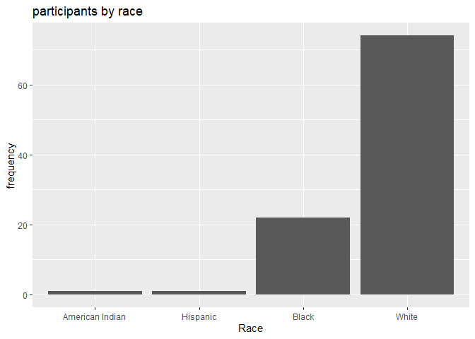

```r
# plot the grapgh using new dataset

ggplot(data = plot_data,
       mapping = aes(x = reorder(race,n), y =n ))+
  geom_bar(stat = "identity") +
  labs(x = "Race",
       y = "frequency",
       title = "participants by race")
```

You can change code reorder(race,n) to reorder(race,desc(n)) or reorder(race,-n)to invert the bar plot so that higher value come first.

#### 2.1.1.4 labelling the bars

You may want to see the label in each bar for better visualization. To do so use *geom_text()* function.

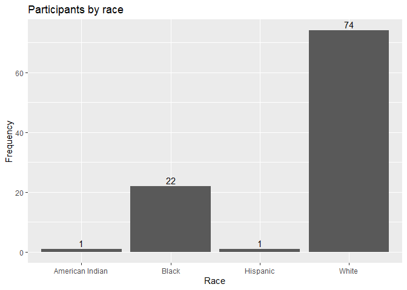

Barchart with numerical labels

```r
# plot the bars with numeric labels
ggplot(plot_data,
       aes(x = race, y = n)) +
  geom_bar(stat="identity") +
  geom_text(aes(label = n), vjust=-0.35) +
  labs(x = "Race",
       y = "Frequency",
       title  = "Participants by race")
```

Here geom_text adds the labels, and vjust controls vertical justification.

Putting these ideas together, you can create a graph like the one below. The minus sign in reorder(race, -pct) is used to order the bars in descending order.

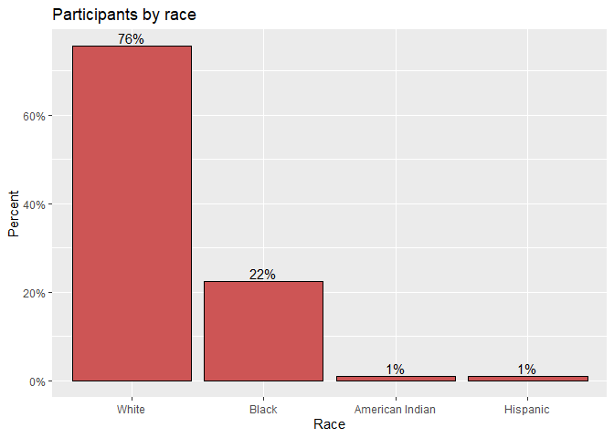

```r
library(dplyr)
library(scales)
plot_data <- Marriage %>%
  count(race) %>%
  mutate(pct = n / sum(n),
         pctlabel = paste0(round(pct*100), "%"))

# plot the bars as percentages,in descending order with bar labels
ggplot(plot_data,
       aes(x = reorder(race, -pct), y = pct)) +
  geom_bar(stat="identity", fill="indianred3", color="black") +
  geom_text(aes(label = pctlabel), vjust=-0.25) +
  scale_y_continuous(labels = scales::percent) +
  labs(x = "Race",
       y = "Percent",
       title  = "Participants by race")
```

#### Overlapping labels

category labels may overlap if thee are many categories or the labels are long. Consider the distribution of marriage officials.

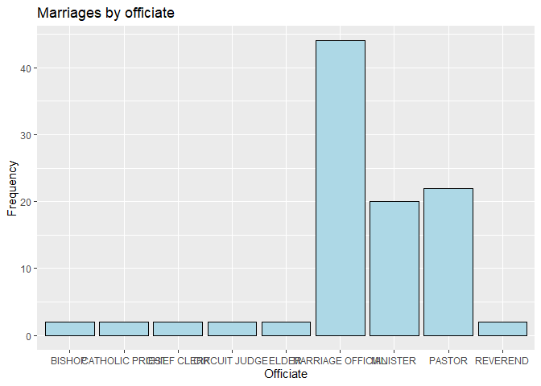

```r
# basic bar chart with overlapping labels
ggplot(Marriage, aes(x=officialTitle)) +
  geom_bar(fill="lightblue", color="black") +
  labs(x = "Officiate",
       y = "Frequency",
       title = "Marriages by officiate")
```

You can flip the x and y axes with the **coord_flip()** function.

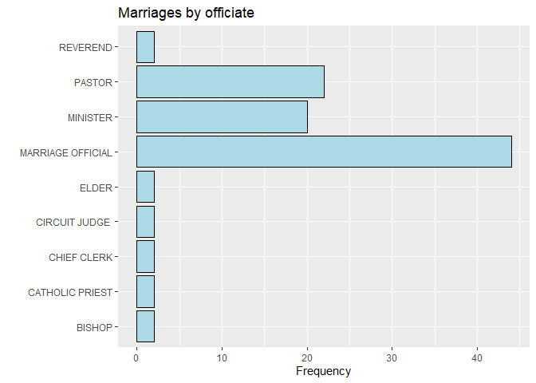

Horizontal Bar chart

```r
# horizontal bar chart
ggplot(Marriage, aes(x = officialTitle)) +
  geom_bar(fill = 'lightblue', color = 'black') +
  labs(x = "",
       y = "Frequency",
       title = "Marriages by officiate") +
  coord_flip()
```

Sometimes its better to rotate the x labels.

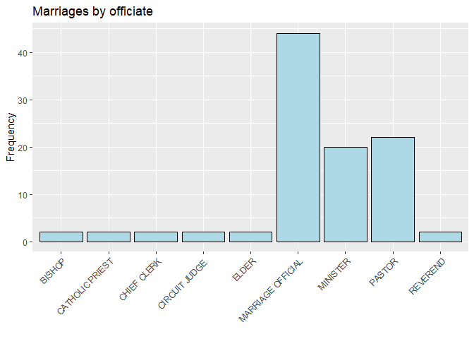

Barchart by rotated x labels

```r
ggplot(data = Marriage,
       mapping = aes(x = officialTitle)) +
  geom_bar(fill = 'lightblue', color = 'black')+
  labs(x = "",
       y = "Frequency",
       title = "Marriages by officiate") +
  theme(axis.text.x = element_text(angle = 45,
                                   hjust = 1))
```

Finally, you can try staggering the labels. The trick is to add a newline to every other label.

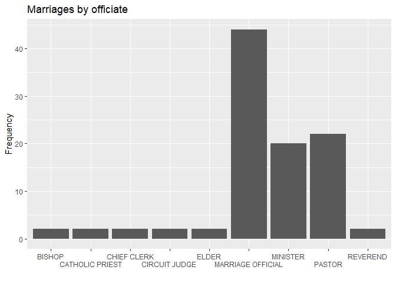

Bar chart by staggered labels

```r
# bar chart with staggered labels
lbls <- paste0(c("","\n"), levels(Marriage$officialTitle))

ggplot(Marriage,
       aes(x=factor(officialTitle,
                    labels = lbls))) +
  geom_bar() +
  labs(x = "",
       y = "Frequency",
       title = "Marriages by officiate")
```

### 2.1.2 Pie chart

Pie charts are controversial in statistics. If your goal is to compare the frequency of categories, you are better off with bar charts and if your goal is compare each category with the the whole and the number of categories is small, then pie charts may work for you.

Pie charts are easily created with ggpie function in the ggpie package. The format is ggpie(data, variable), where data is a data frame, and variable is the categorical variable to be plotted.

#### 2.1.2.1 Without label

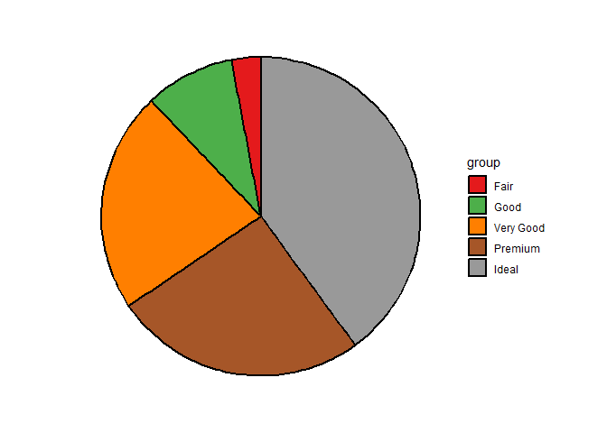

```r
library(ggpie)
library(ggplot2)
# with no label
ggpie(
  data = diamonds, group_key = "cut", count_type = "full",
  label_info = "all", label_type = "none"
)
```

#### circle label and out of pie

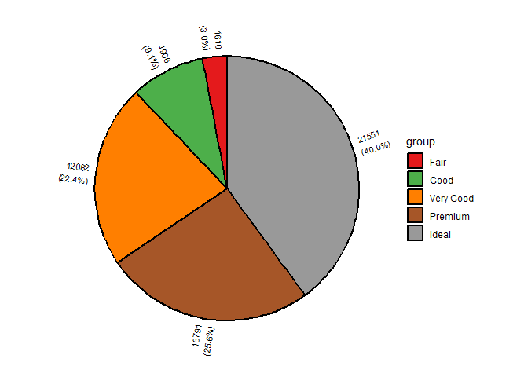

```r
# circle label and out of pie
ggpie(
  data = diamonds, group_key = "cut", count_type = "full",
  label_info = "all", label_type = "circle",
  label_size = 3, label_pos = "out"
)
```

#### 2.1.2.2 circle label and in pie plot, with no split

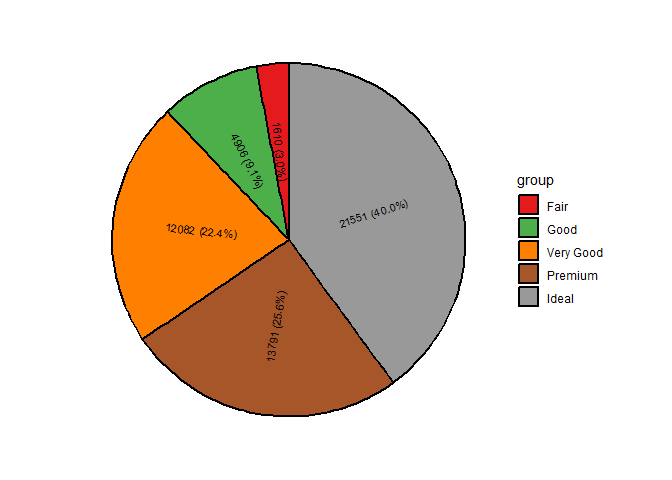

```r
# circle label and in pie plot, with no split
ggpie(
  data = diamonds, group_key = "cut", count_type = "full",
  label_info = "all", label_type = "circle", label_split = NULL,
  label_size = 3, label_pos = "in"
)
```

#### 2.1.2.3 horizon label and in pie plot, with no split

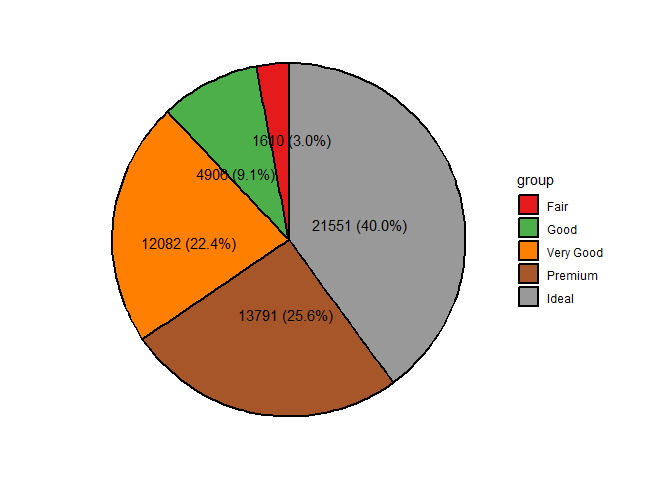

```r
# horizon label and in pie plot, with no split
ggpie(
  data = diamonds, group_key = "cut", count_type = "full",
  label_info = "all", label_type = "horizon", label_split = NULL,
  label_size = 4, label_pos = "in"
)
```

#### 2.1.2.4 horizon label and in pie plot, split with space

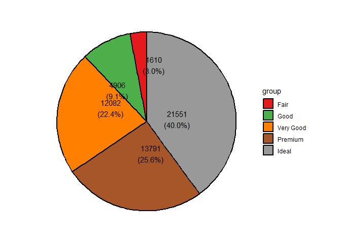

```r
# horizon label and in pie plot, split with space
ggpie(
  data = diamonds, group_key = "cut", count_type = "full",
  label_info = "all", label_type = "horizon",
  label_size = 4, label_pos = "in"
)
```

#### 2.1.2.5 horizon label and out pie plot, with no split

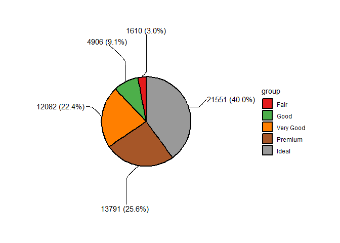

```r
# horizon label and out pie plot, with no split
ggpie(
  data = diamonds, group_key = "cut", count_type = "full",
  label_info = "all", label_type = "horizon", label_split = NULL,
  label_size = 4, label_pos = "out"
)
```

#### 2.1.2.6 with label threshold

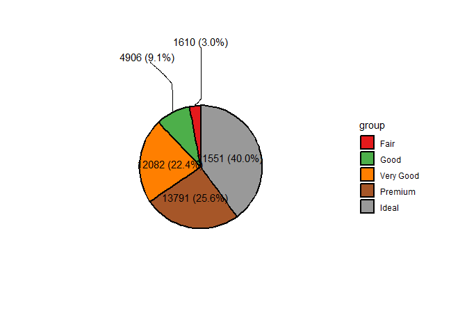

```r
# with label threshold
ggpie(
  data = diamonds, group_key = "cut", count_type = "full",
  label_info = "all", label_type = "horizon", label_split = NULL,
  label_size = 4, label_pos = "in", label_threshold = 10)
```

These are the different type of style in ggpie for pi chart. This is the example in package documentation in R.

### 2.1.3 Tree map

An alternative to the pie chart is a tree map. Unlike pie charts, it can handle categorical variables that have many levels. For this we need a *treemapify* package.

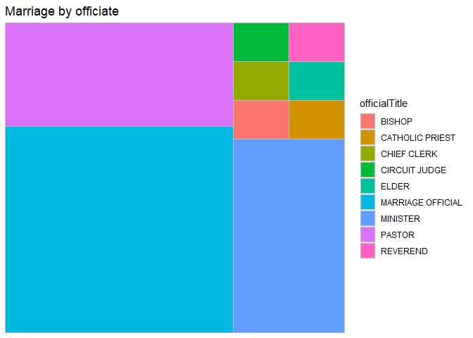

```r
if (!requireNamespace("treemapify", quietly = TRUE)) {
  install.packages("treemapify")
}
library(dplyr)
library(mosaicData)
library(treemapify)
library(ggplot2)

# create a treemap of marriage officials
plot_data <- Marriage %>%
  count(officialTitle)

ggplot(plot_data,
       aes(fill = officialTitle,
           area = n)) +
  geom_treemap() +
  labs(title = "Marriage by officiate")
```

Now with better labels

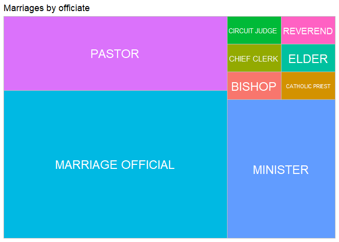

```r
# create a treemap with tile labels
ggplot(plot_data,
       aes(fill = officialTitle,
           area = n,
           label = officialTitle)) +
  geom_treemap() +
  geom_treemap_text(colour = "white",
                    place = "centre") +
  labs(title = "Marriages by officiate") +
  theme(legend.position = "none")
```

Now add label = n in aes to add the numbers in the tree map.

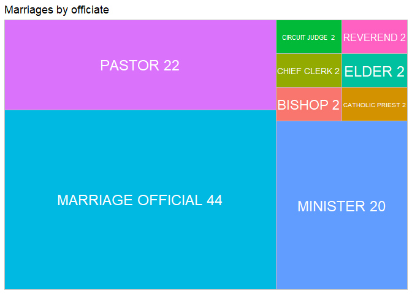

```r
# create a treemap with tile labels
ggplot(plot_data,
       aes(fill = officialTitle,
           area = n,
           label = paste0(officialTitle," ",n))) +
  geom_treemap() +
  geom_treemap_text(colour = "white",
                    place = "centre") +
  labs(title = "Marriages by officiate") +
  theme(legend.position = "none")
```

### 2.1.4 Wafle Chart

A waffle chart, sometimes called a gridplot or square pie chart, is a visualization that presents data using squares in a grid, where each square represents a portion or percentage of the whole. In R, you can construct a waffle chart using the geom_waffle function from the waffle package.

Now, let’s create a waffle chart to visualize the distribution of wedding officiant professions. As with tree maps, we begin by summarizing the data into groups and counting the occurrences of each profession.

Let’s create a waffle chart for the professions of wedding officiates. As with tree maps, start by summarizing the data into groups and counts.

```r
library(dplyr)
plot_data <- Marriage %>%
  count(officialTitle)
```

Next, create the ggplot2 grapgh. Set *fill* to the grouping variables and *values* to the counts. Don’t specify an *x* and *y*.

The following code produces the default waffle plot.

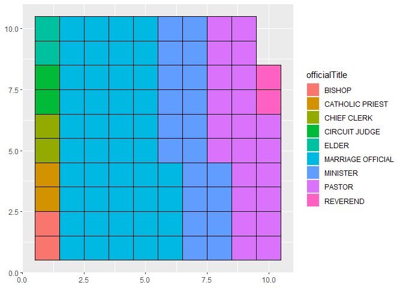

```r
# create a basic waffle chart
if (!requireNamespace("waffle", quietly = TRUE)) {
  install.packages("waffle")
}
library(waffle)
ggplot(plot_data, aes(fill = officialTitle, values=n)) +
  geom_waffle(na.rm=TRUE)
```

## 2.2 Quantitative

In the Marriage dataset, age is quantitative variable. The distribution of a single quantitative variable is typically plotted with a histogram, kernel density plot, or dot plot.

### 2.2.1 Histogram

Histograms are the most common approach to visualizing a quantitative variable. In a histogram, the values of a variable are typically divided up into adjacent, equal width ranges(bins), and the number of observations in each bin is plotted with a vertical bar.

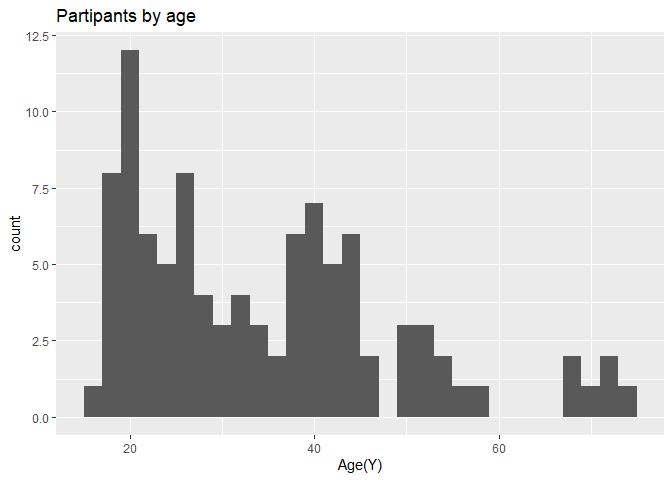

Basic histogram Plot

```r
library(ggplot2)
library(mosaicData)

# plot the age distribution using histogram

ggplot(Marriage, aes(x = age)) +
  geom_histogram() +
  labs(title = "Partipants by age",
       x = "Age(Y)")
```

Histogram colors can be modified using two options

- fill : fill color for the bars
- color : border color around the bars

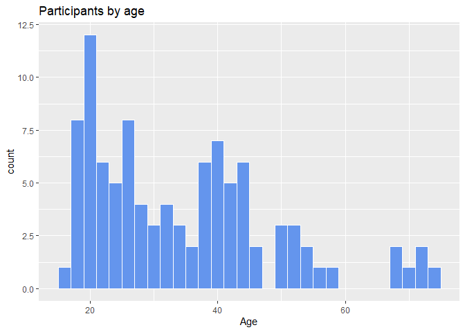

Histogram with modified color

```r
# plot the histogram with blue bars and white borders
ggplot(Marriage, aes(x = age)) +
  geom_histogram(fill = "cornflowerblue",
                 color = "white") +
  labs(title="Participants by age",
       x = "Age")
```